# Домашнее задание №1

YASINOVSKY/OSTAPENKO

18 декабря 2016 г

# Работа с данными.

Загрузил данные в датафрейм data.df

```r
data.df <- read.table("http://www.stats.uwo.ca/faculty/braun/data/rnf6080.dat")
```

Колличество строк

```r
dim(data.df)[1]
```

```
## [1] 5070
```

Колличество столбцов

```r
dim(data.df)[2]
```

```
## [1] 27
```

Получил имена столбцов

```r
colnames(data.df)
```

```
##  [1] "V1"  "V2"  "V3"  "V4"  "V5"  "V6"  "V7"  "V8"  "V9"  "V10" "V11"
## [12] "V12" "V13" "V14" "V15" "V16" "V17" "V18" "V19" "V20" "V21" "V22"
## [23] "V23" "V24" "V25" "V26" "V27"
```

Нашел значение из 5 строки 7 столбца

```r
data.df[5,7]
```

```
## [1] 0
```

Целиком 2 строка

```r
data.df[2,]
```

```
##   V1 V2 V3 V4 V5 V6 V7 V8 V9 V10 V11 V12 V13 V14 V15 V16 V17 V18 V19 V20
## 2 60  4  2  0  0  0  0  0  0   0   0   0   0   0   0   0   0   0   0   0
##   V21 V22 V23 V24 V25 V26 V27
## 2   0   0   0   0   0   0   0
```

Первые 3 значение обозначают год, месяц, день. Seq - время 24.

```r
names(data.df) <- c("year", "month", "day", seq(0,23))
```

Функции Head and Tail показывают начало и конец фрейма построчно.

```r
head(data.df)
```

```
##   year month day 0 1 2 3 4 5 6 7 8 9 10 11 12 13 14 15 16 17 18 19 20 21
## 1   60     4   1 0 0 0 0 0 0 0 0 0 0  0  0  0  0  0  0  0  0  0  0  0  0
## 2   60     4   2 0 0 0 0 0 0 0 0 0 0  0  0  0  0  0  0  0  0  0  0  0  0
## 3   60     4   3 0 0 0 0 0 0 0 0 0 0  0  0  0  0  0  0  0  0  0  0  0  0
## 4   60     4   4 0 0 0 0 0 0 0 0 0 0  0  0  0  0  0  0  0  0  0  0  0  0
## 5   60     4   5 0 0 0 0 0 0 0 0 0 0  0  0  0  0  0  0  0  0  0  0  0  0
## 6   60     4   6 0 0 0 0 0 0 0 0 0 0  0  0  0  0  0  0  0  0  0  0  0  0
##   22 23
## 1  0  0
## 2  0  0
## 3  0  0
## 4  0  0
## 5  0  0
## 6  0  0
```

```r
tail(data.df)
```

```
##      year month day 0 1 2 3 4 5 6 7 8 9 10 11 12 13 14 15 16 17 18 19 20
## 5065   80    11  25 0 0 0 0 0 0 0 0 0 0  0  0  0  0  0  0  0  0  0  0  0
## 5066   80    11  26 0 0 0 0 0 0 0 0 0 0  0  0  0  0  0  0  0  0  0  0  0
## 5067   80    11  27 0 0 0 0 0 0 0 0 0 0  0  0  0  0  0  0  0  0  0  0  0
## 5068   80    11  28 0 0 0 0 0 0 0 0 0 0  0  0  0  0  0  0  0  0  0  0  0
## 5069   80    11  29 0 0 0 0 0 0 0 0 0 0  0  0  0  0  0  0  0  0  0  0  0
## 5070   80    11  30 0 0 0 0 0 0 0 0 0 0  0  0  0  0  0  0  0  0  0  0  0
##      21 22 23
## 5065  0  0  0
## 5066  0  0  0
## 5067  0  0  0
## 5068  0  0  0
## 5069  0  0  0
## 5070  0  0  0
```

Добавил новую колонку с названием daily, записал суммукрайних правых 24 колонок.

```r
data.df$daily <- apply(FUN=sum, X = data.df[,4:27], MARGIN=1)
```

Построил гистограмму по данной колонке. По результатам построенной гистограммы можно сделать выводы, что осадки ушли в отрицательное значение.

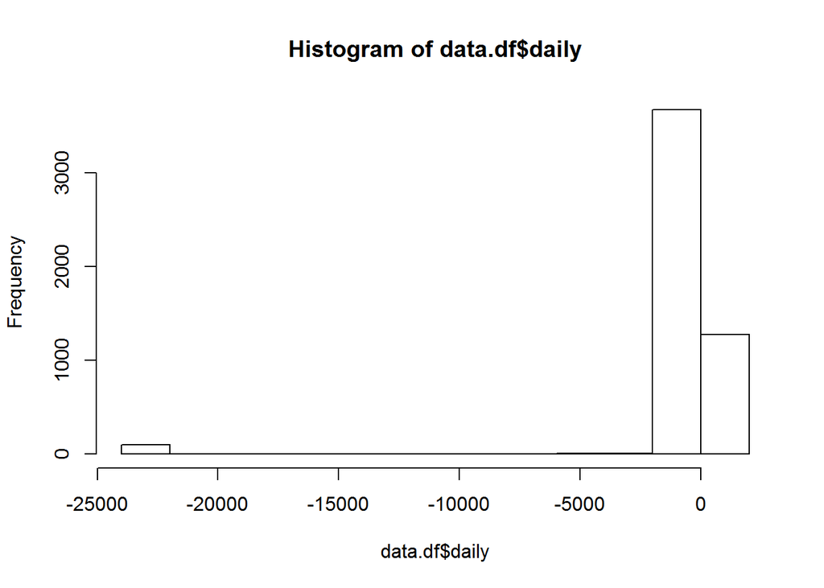

```r
hist(data.df$daily)
```

Создал новыфй датафрейм fixed.df. Построил новую исправленную гистограмму.

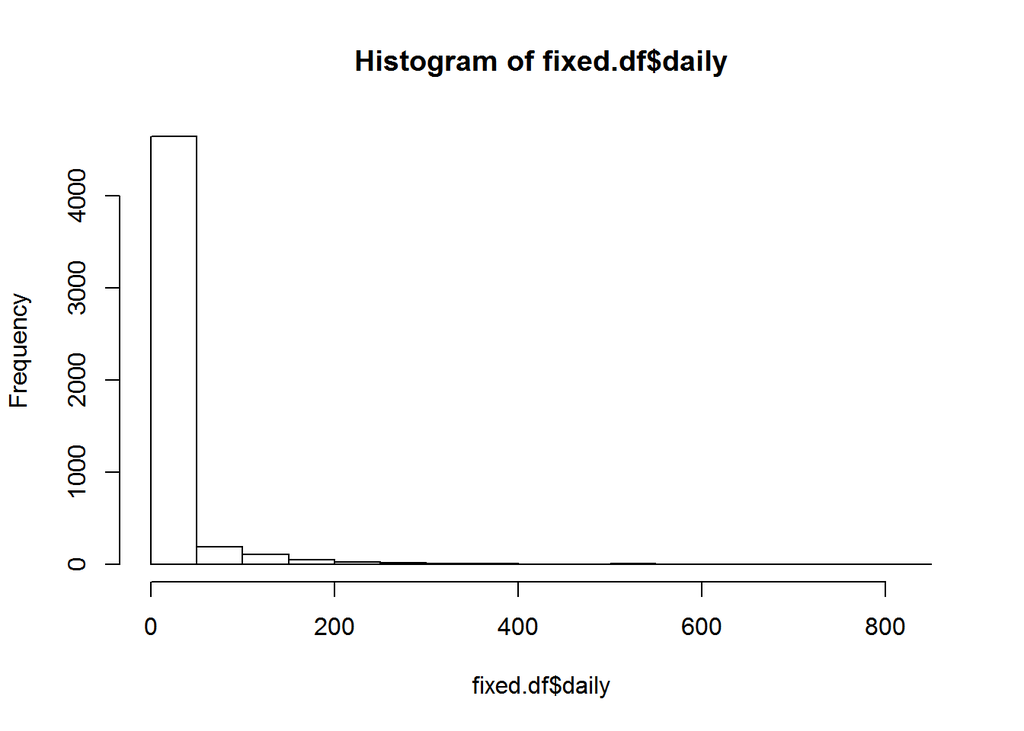

```r
fixed.df <- data.df
fixed.df$daily[fixed.df$daily<0]<-0
hist(fixed.df$daily)
```

# Синтаксис и типизирование

Ошибка в sum(v). Неправильный ‘type’(character) аргумент вызова. v <- c(“4”, “8”, “15”, “16”, “23”, “42”) max(v) sort(v) sum(v)

Обращение к списку без продолжения. Ошибка в соедении строк.

```r
  v2 <- c("5",7,12)
  #v2[2] + v2[3]

  df3 <- data.frame(z1="5",z2=7,z3=12)
  df3[1,2] + df3[1,3]
```

```
## [1] 19
```

```r
  l4 <- list(z1="6", z2=42, z3="49", z4=126)
  l4[[2]] + l4[[4]]
```

```
## [1] 168
```

```r
  #l4[2] + l4[4]
```

# Работа с функциями и операторами

Число от 1 до 10000 с инкрементом 372.

```r
seq(1, 10000, by=372)
```

```
##  [1]    1  373  745 1117 1489 1861 2233 2605 2977 3349 3721 4093 4465 4837
## [15] 5209 5581 5953 6325 6697 7069 7441 7813 8185 8557 8929 9301 9673
```

Числа от 1 до 10000 длиной 50.

```r
seq(1, 10000, length.out = 50)
```

```
##  [1]     1.0000   205.0612   409.1224   613.1837   817.2449  1021.3061
##  [7]  1225.3673  1429.4286  1633.4898  1837.5510  2041.6122  2245.6735
## [13]  2449.7347  2653.7959  2857.8571  3061.9184  3265.9796  3470.0408
## [19]  3674.1020  3878.1633  4082.2245  4286.2857  4490.3469  4694.4082
## [25]  4898.4694  5102.5306  5306.5918  5510.6531  5714.7143  5918.7755
## [31]  6122.8367  6326.8980  6530.9592  6735.0204  6939.0816  7143.1429
## [37]  7347.2041  7551.2653  7755.3265  7959.3878  8163.4490  8367.5102
## [43]  8571.5714  8775.6327  8979.6939  9183.7551  9387.8163  9591.8776
## [49]  9795.9388 10000.0000
```

Функция rep() повторяет переданный вектор указанное число раз. Объясните разницу между rep(1:5,times=3) и rep(1:5, each=3).

Различие заключается в том, что в первом случае последовательность повторяется целиком 3 раза, а во втором случае, происходит повторение каждого элемента 3 раза